# EDA on Prosper Loan Data by Dalal Alwedaah

# Introduction

In this project we investigat Prosper loan database, which is a peer-to-peer lending website Founded in 2005. We try to find distribution of single variables and the intrested correlations between variables.

# Data Overview

Prosper dataset contain 113937 observations and 81 variables.

```
## [1] 113937     81
```

There is the varibales names list

```
##  [1] "ListingKey"
##  [2] "ListingNumber"
##  [3] "ListingCreationDate"
##  [4] "CreditGrade"
##  [5] "Term"
##  [6] "LoanStatus"
##  [7] "ClosedDate"
##  [8] "BorrowerAPR"
##  [9] "BorrowerRate"
## [10] "LenderYield"
## [11] "EstimatedEffectiveYield"
## [12] "EstimatedLoss"
## [13] "EstimatedReturn"
## [14] "ProsperRating..numeric."
## [15] "ProsperRating..Alpha."
```

[output cut: 66 more lines]

and here is the structure of Prosper dataset

```
## 'data.frame':    113937 obs. of  81 variables:
##  $ ListingKey                         : Factor w/ 113066 levels "00003546482094282EF90E5",..: 7180 7193 6647 6669 6686 6689 6699 6706 6687 6687 ...
##  $ ListingNumber                      : int  193129 1209647 81716 658116 909464 1074836 750899 768193 1023355 1023355 ...
##  $ ListingCreationDate                : Factor w/ 113064 levels "2005-11-09 20:44:28.847000000",..: 14184 111894 6429 64760 85967 100310 72556 74019 97834 97834 ...
##  $ CreditGrade                        : Factor w/ 9 levels "","A","AA","B",..: 5 1 8 1 1 1 1 1 1 1 ...
##  $ Term                               : int  36 36 36 36 36 60 36 36 36 36 ...
##  $ LoanStatus                         : Factor w/ 12 levels "Cancelled","Chargedoff",..: 3 4 3 4 4 4 4 4 4 4 ...
##  $ ClosedDate                         : Factor w/ 2803 levels "","2005-11-25 00:00:00",..: 1138 1 1263 1 1 1 1 1 1 1 ...
##  $ BorrowerAPR                        : num  0.165 0.12 0.283 0.125 0.246 ...
##  $ BorrowerRate                       : num  0.158 0.092 0.275 0.0974 0.2085 ...
##  $ LenderYield                        : num  0.138 0.082 0.24 0.0874 0.1985 ...
##  $ EstimatedEffectiveYield            : num  NA 0.0796 NA 0.0849 0.1832 ...
##  $ EstimatedLoss                      : num  NA 0.0249 NA 0.0249 0.0925 ...
##  $ EstimatedReturn                    : num  NA 0.0547 NA 0.06 0.0907 ...
##  $ ProsperRating..numeric.            : int  NA 6 NA 6 3 5 2 4 7 7 ...
```

[output cut: 67 more lines]

# Univariate Analysis

### What is the structure of your dataset?

Prosper dataset contain contain 113937 observations and 81 variables. there are three kinds of variables: numerical variables like (Investors and LenderYield) and factorial variables like (IsBorrowerHomeowner and IncomeRange). I transfer some factorial variable from numerical lables into meaningful lables like (IncomeRange and ListingCategory..numeric) which make our visualisation more undrestandable.

First, we explor loan status of all loans. we can see that most of them are current or completed loans.

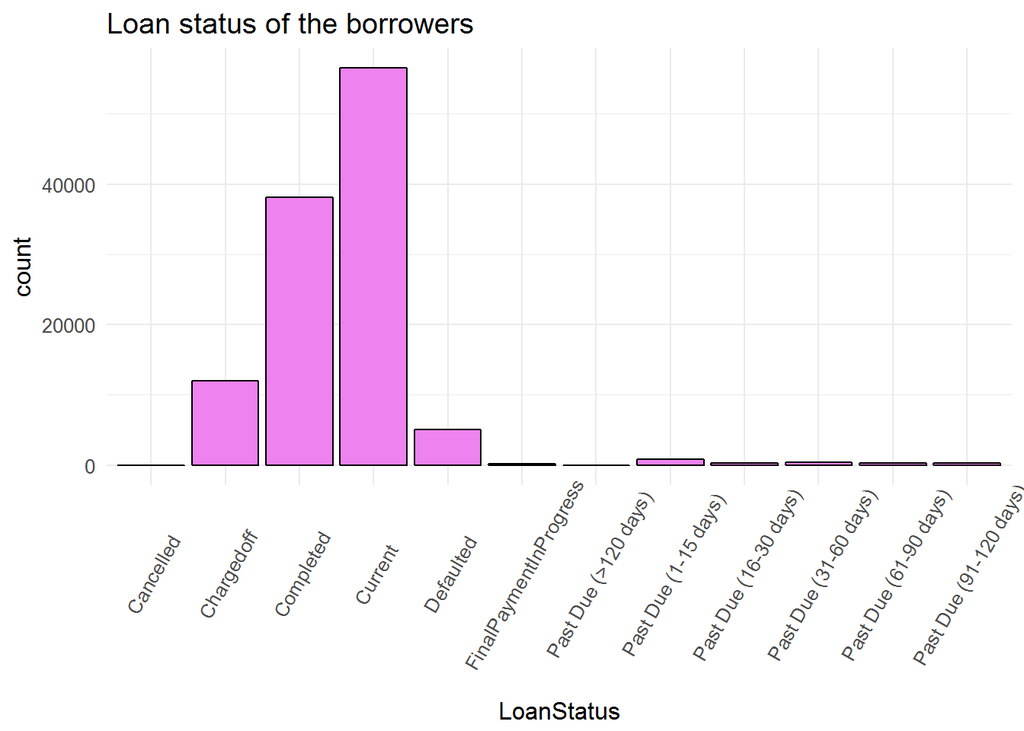

Then, we take a log to be more clear.

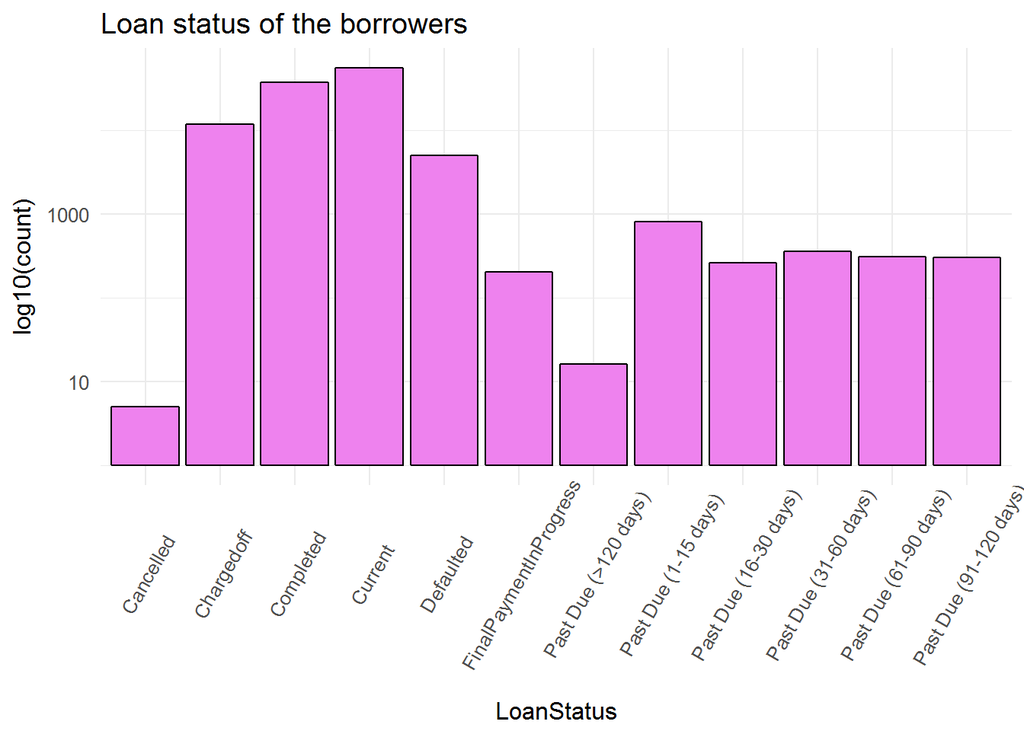

Then, we try to collaps all past due loans categories(“Past Due (>120 days)”, “Past Due (1-15 days)”, “Past Due (16-30 days)”, “Past Due (31-60 days)”, “Past Due (61-90 days)”,and “Past Due (91-120 days)”) in one category label “PastDue”.

```
##  [1] Completed              Current                Past Due (1-15 days)
##  [4] Defaulted              Chargedoff             Past Due (16-30 days)
##  [7] Cancelled              Past Due (61-90 days)  Past Due (31-60 days)
## [10] Past Due (91-120 days) FinalPaymentInProgress Past Due (>120 days)
## 12 Levels: Cancelled Chargedoff Completed Current ... Past Due (91-120 days)
```

```
##  Factor w/ 12 levels "Cancelled","Chargedoff",..: 3 4 3 4 4 4 4 4 4 4 ...
```

```
##  Factor w/ 7 levels "Cancelled","Chargedoff",..: 3 4 3 4 4 4 4 4 4 4 ...
```

```
##
##              Cancelled             Chargedoff              Completed
##                      5                  11992                  38074
##                Current              Defaulted FinalPaymentInProgress
##                  56576                   5018                    205
##                PastDue
##                   2067
```

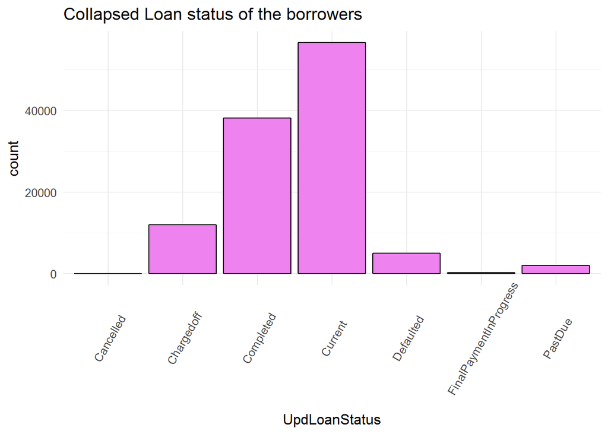

We try to see distribution of lenders’ yield on the loan but its unclear

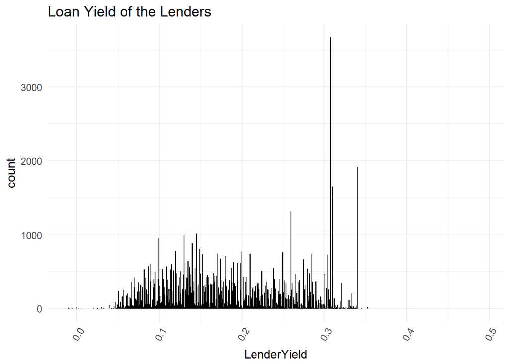

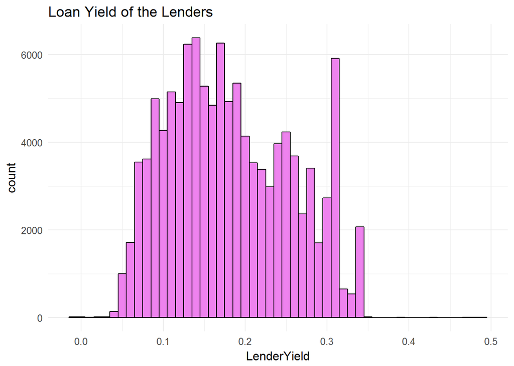

The Prosper Rating assigned to loans after July 2009 and it have tow forms numeric and alpha 0 - N/A, 1 - HR, 2 - E, 3 - D, 4 - C, 5 - B, 6 - A, 7 - AA. Prosper rateing is a rate by poster to buyers where HR is the worst rating and AA is the best rating. We can see there are a lot of unrated loans about 29084 ones.

```
##    Min. 1st Qu.  Median    Mean 3rd Qu.    Max.    NA's
##   1.000   3.000   4.000   4.072   5.000   7.000   29084
```

```
##           A    AA     B     C     D     E    HR
## 29084 14551  5372 15581 18345 14274  9795  6935
```

Graphs show That Prosper Rating is normaly distrebuted.

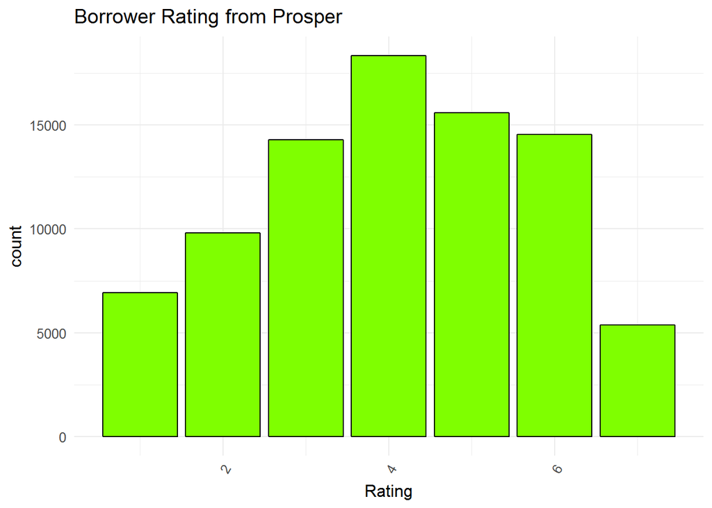

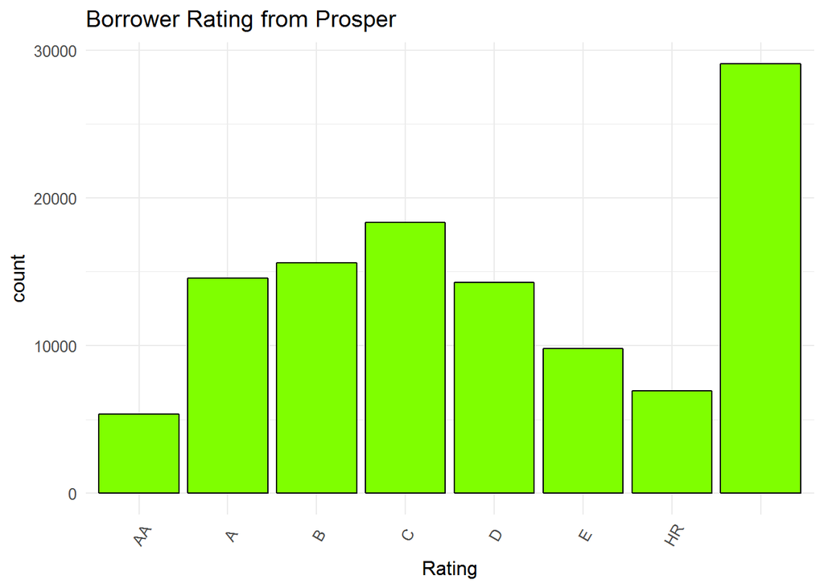

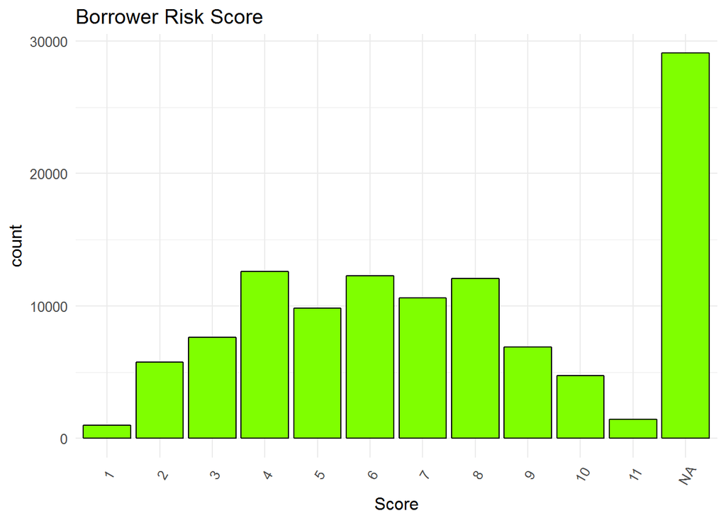

About the purpose of the loan, we notice most of borrowers use loan for debt consolidation then for main needs like :home improvement and business.

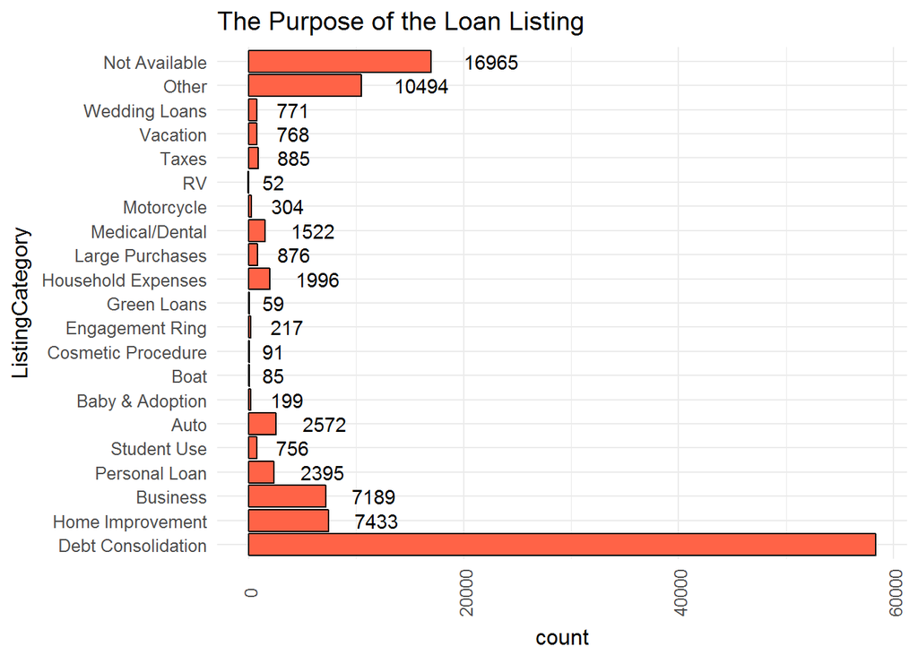

in the bellow map we can see most brrowers from Texas, Illinois, California, Georgia, Ohio, Michigan, Florida, New York, New Jersey, and Virginia. these states also have largest gross state product (GSP) and economic activity. North Dakota is the state with the lowest number of borrowers which also have low GSP among states.

[interactive chart not shown]

we take a look on borrowers’ occupation when we exclude “other” option, the Professional is the most occupation of the borrowers (13628). #it will be better if we have general catagories or sectors like health and education#.

```
##                                  Var1  Freq
## 1                                      3588
## 2                      Accountant/CPA  3233
## 3            Administrative Assistant  3688
## 4                             Analyst  3602
## 5                           Architect   213
## 6                            Attorney  1046
## 7                           Biologist   125
## 8                          Bus Driver   316
## 9                          Car Dealer   180
## 10                            Chemist   145
## 11                      Civil Service  1457
## 12                             Clergy   196
## 13                           Clerical  3164
## 14                Computer Programmer  4478
```

[output cut: 54 more lines]

we can see that most of borrwoers are employed and have full-time jobs.

```
## [1] ""              "Employed"      "Full-time"     "Not available"
## [5] "Not employed"  "Other"         "Part-time"     "Retired"
## [9] "Self-employed"
```

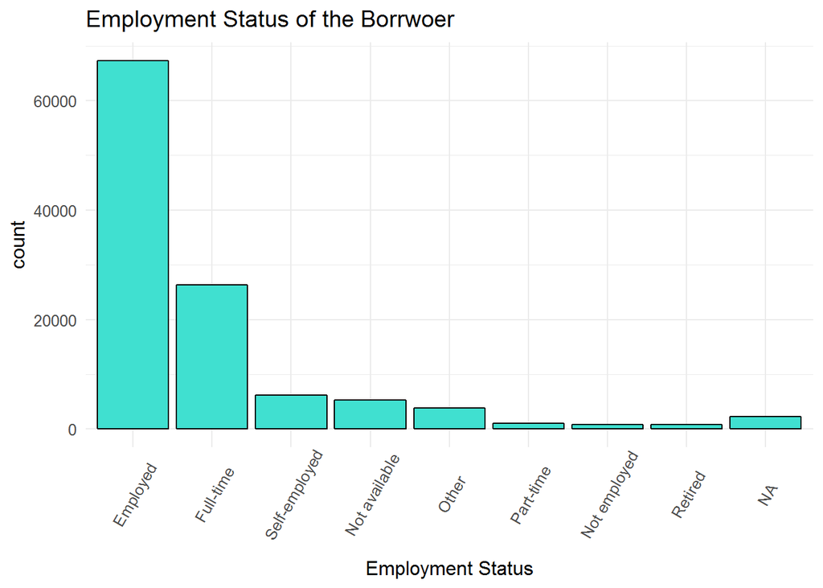

We can see that about half of borrowers were homeowner and other half were not.

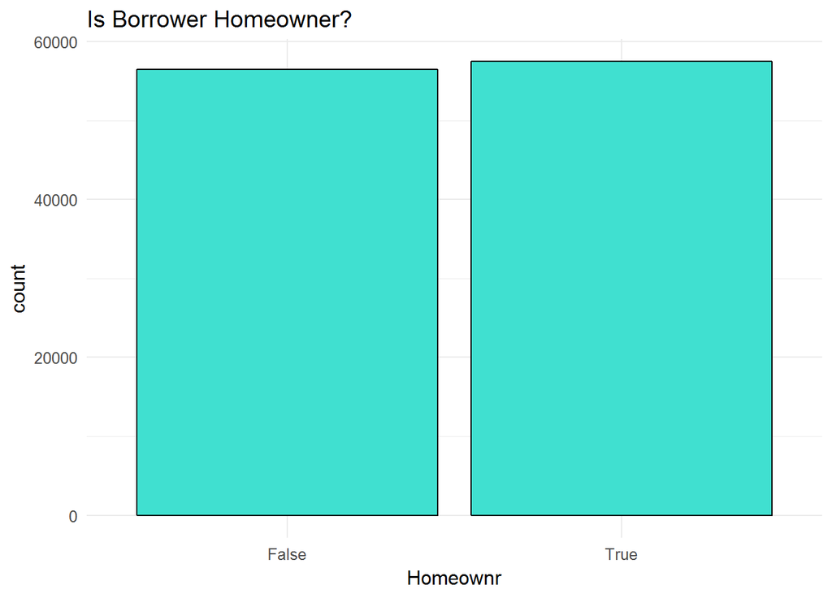

We can see that available bank credit is right skewed distribution.

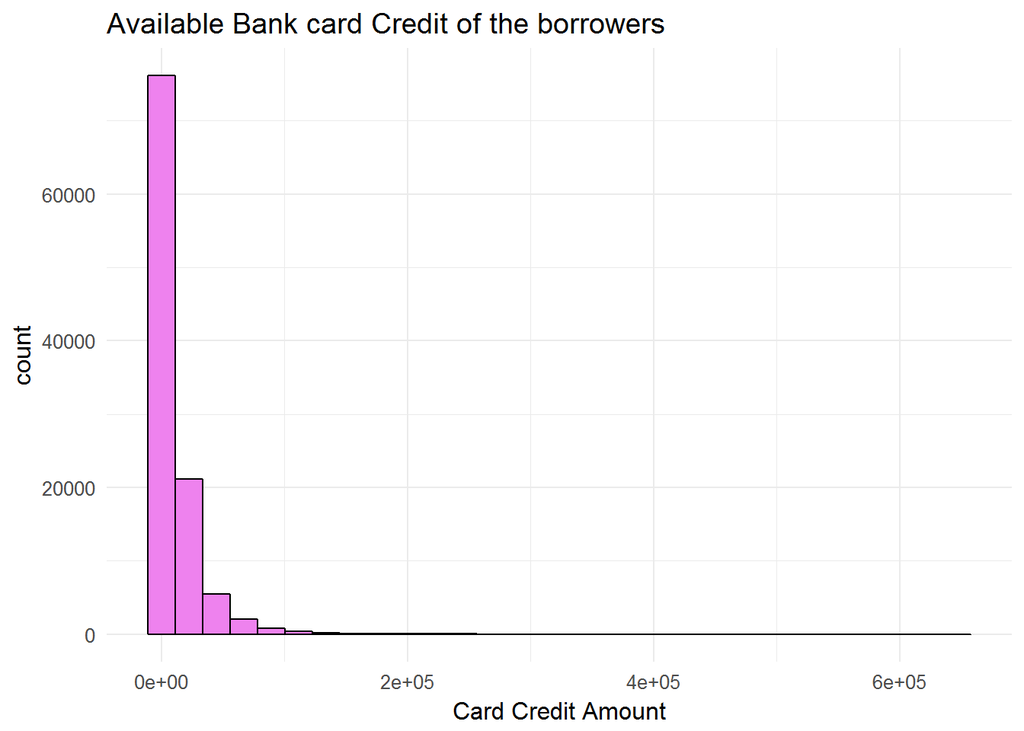

there are 12425 borrwoer has zero amount and we exclud them for closer look at the data. The mean of available bank credit is 11210 and the median is 4100.

```
##  num [1:113937] 1500 10266 NA 30754 695 ...
```

```
##    Min. 1st Qu.  Median    Mean 3rd Qu.    Max.    NA's
##       0     880    4100   11210   13180  646300    7544
```

```
## [1] 12425    84
```

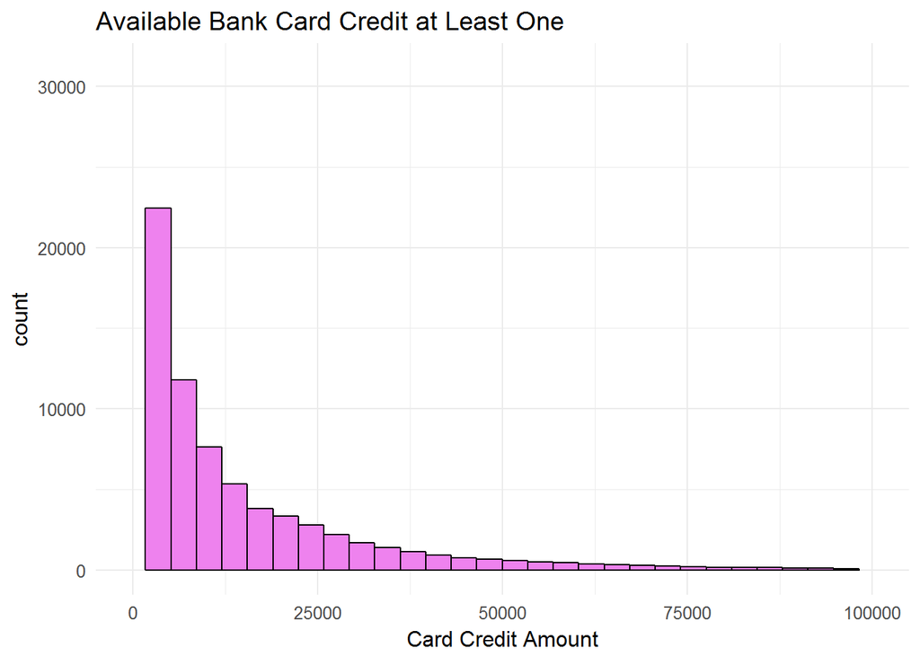

We can see that most of borrowers’ income between $25,000 and $74,999 and bi distribution. this mean the middel layer for each social class take loans more than anothers.

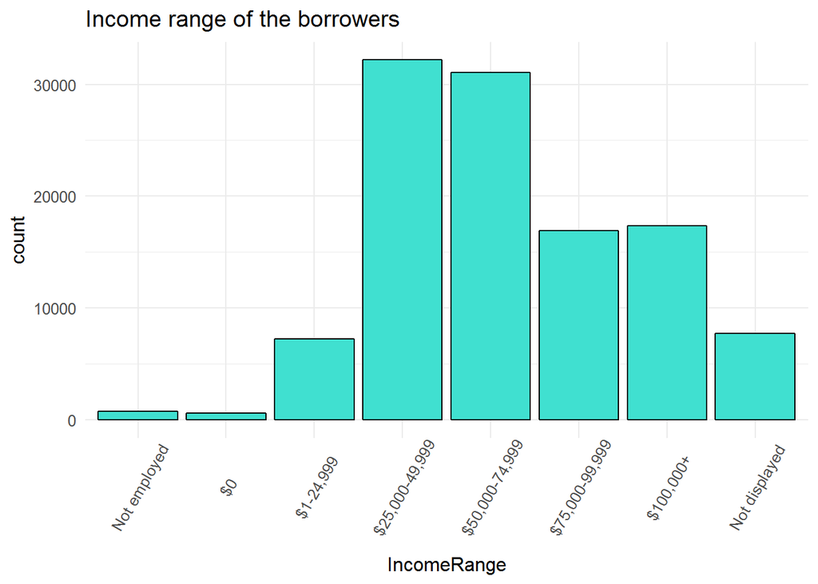

The graph below show that we can trust the income result because it almost verified.

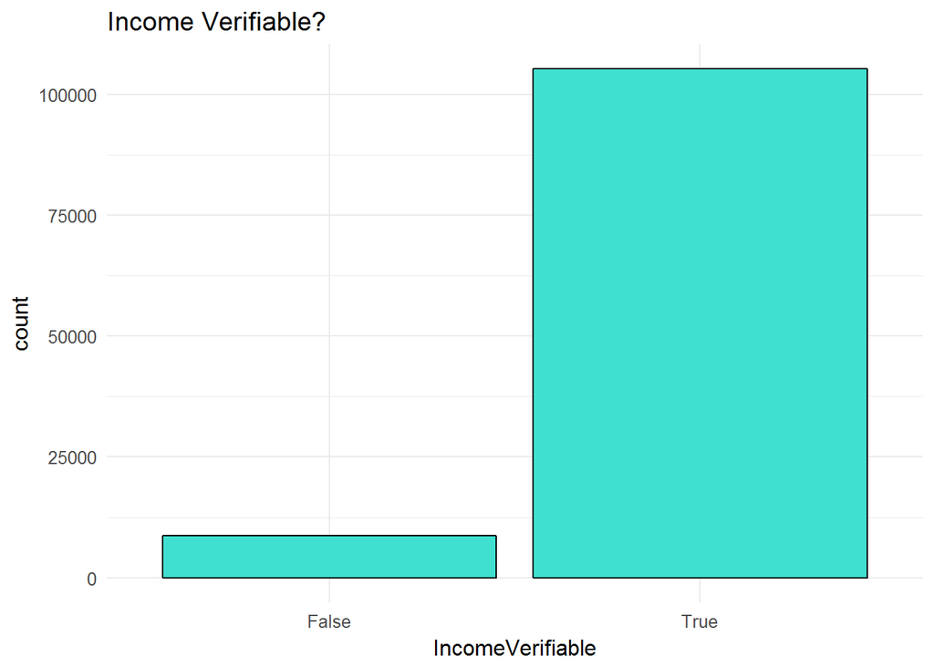

We can see that graph is right skewed and most of borrowers keep it under 0.50.

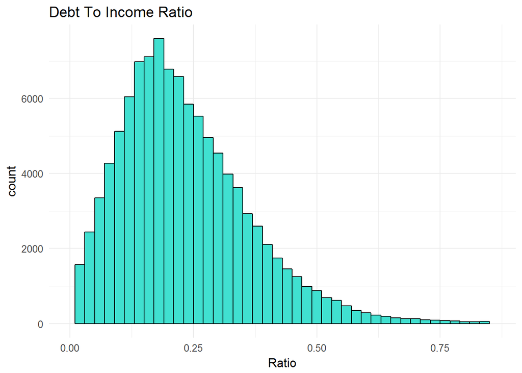

We can see that graph is right skewed and most of loans between zero and tow Recommendations.

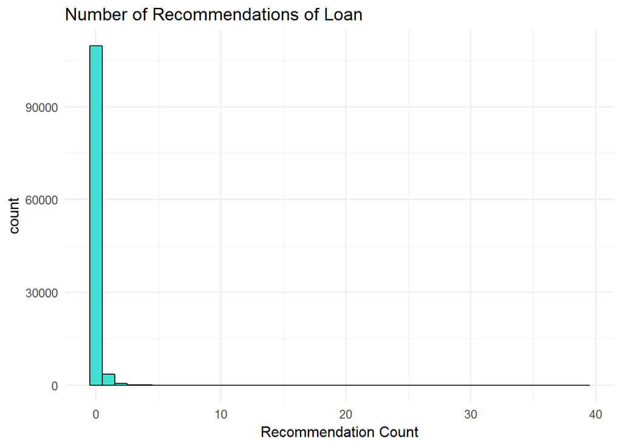

there are 109678 loans with zero recommendations,3516 loans with one recommendations and 568 loans with tow recommendations. we exclude all them from the graph to show others clearly. there is only one loan have 39 recommendations.

```
##     Min.  1st Qu.   Median     Mean  3rd Qu.     Max.
##  0.00000  0.00000  0.00000  0.04803  0.00000 39.00000
```

```
## [1] 109678     84
```

```
## [1] 3516   84
```

```
## [1] 568  84
```

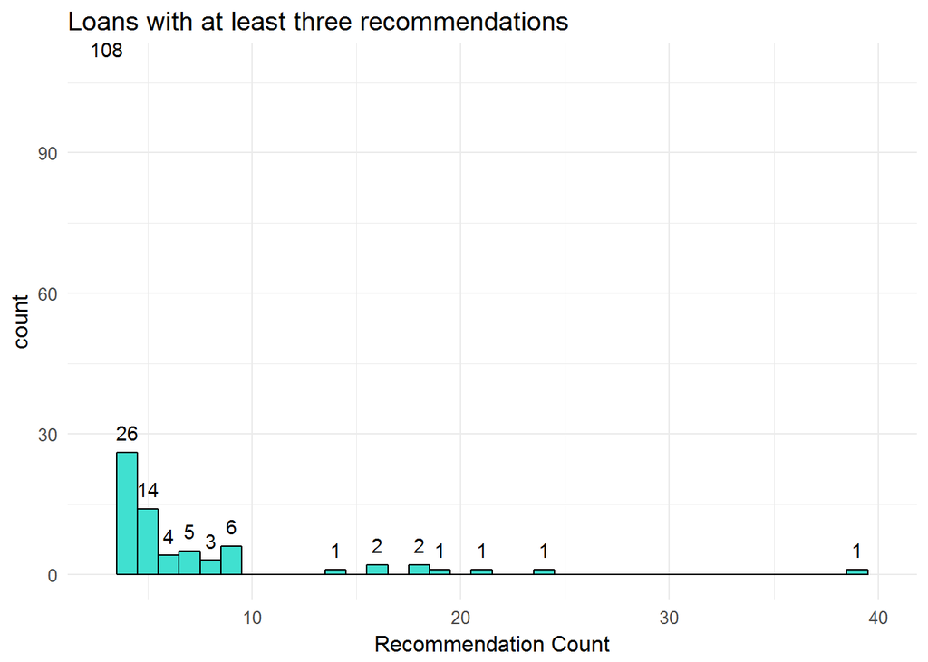

In investors graph, we can see it right skewed and most of loans have between 1 to 50 investor.

```
##    Min. 1st Qu.  Median    Mean 3rd Qu.    Max.
##    1.00    2.00   44.00   80.48  115.00 1189.00
```

```
## [1] 27814    84
```

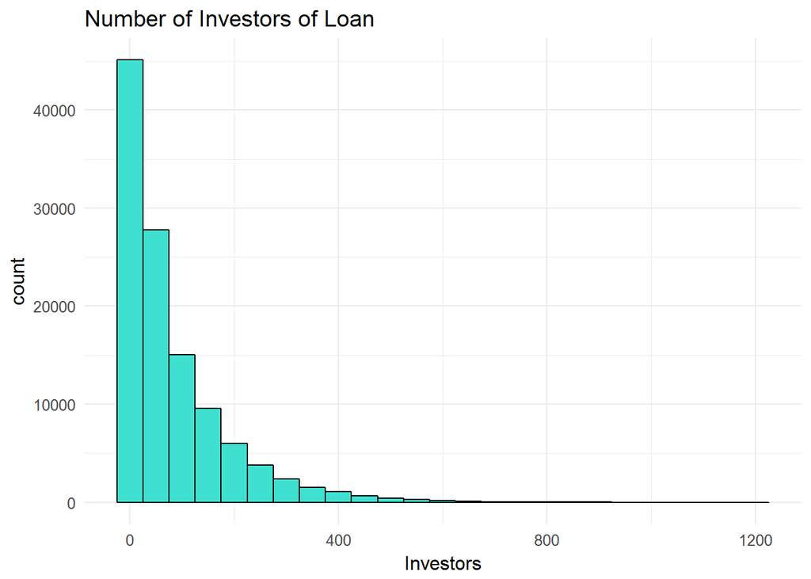

We can see that most of loans are for 36 months.

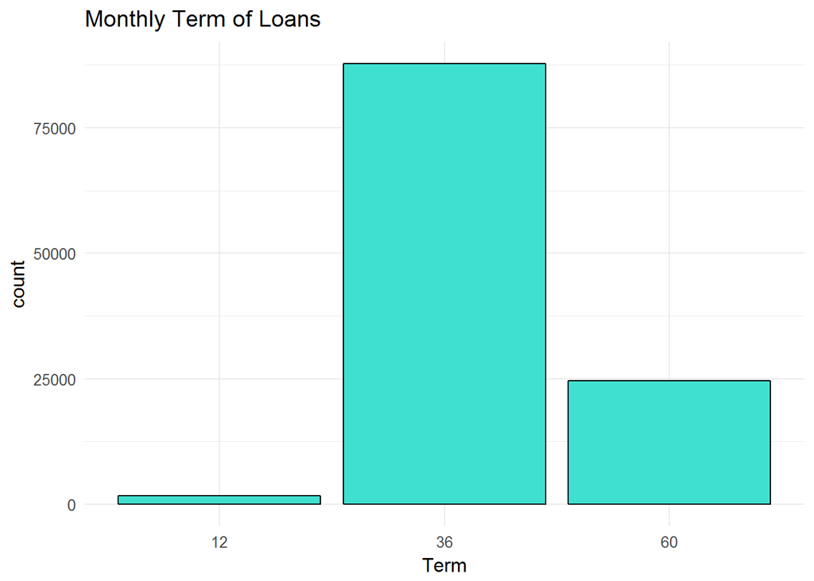

### What is/are the main feature(s) of interest in your dataset?

I interest in LoanStatus and LenderYield. lender yield is an important for how much you will earn as a lender and which varibale effect invesment selection. From loan status we can see characteristics of whome payed on time or late. then, I want to know which variables impact on these tow variables.

### What other features in the dataset do you think will help support your investigation into your feature(s) of interest?

ProsperRating will have an impacts on LenderYield because risk increas when you lend to low rate person. Also, there are many related variables like IncomeRange, Term, DebtToIncomeRatio, availablebankcredit, and Recommendation.

### Did you create any new variables from existing variables in the dataset?

Yes, I add count of each state on the map.

### Of the features you investigated, were there any unusual distributions? Did you perform any operations on the data to tidy, adjust, or change the form of the data? If so, why did you do this?

there are tow variabales Available Bankcard Credit and the number of Recommendations are heavily right skewed because most of there values are zero. I change some variables to factor format and add meaningful lables to them.

# Bivariate Plots Section

```
## [1] "LenderYield"             "Term"
## [3] "ProsperRating..numeric." "ProsperScore"
## [5] "IncomeRange"             "DebtToIncomeRatio"
```

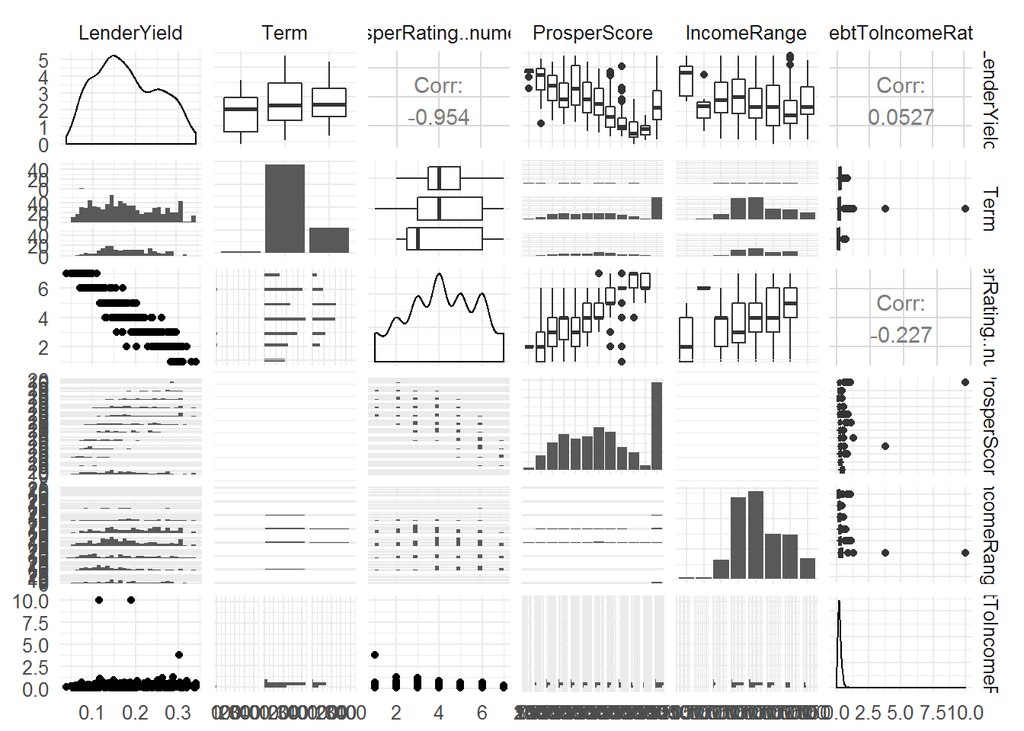

```
## [1] "LoanStatus"              "Term"
## [3] "ProsperRating..numeric." "ProsperScore"
## [5] "IncomeRange"             "DebtToIncomeRatio"
```

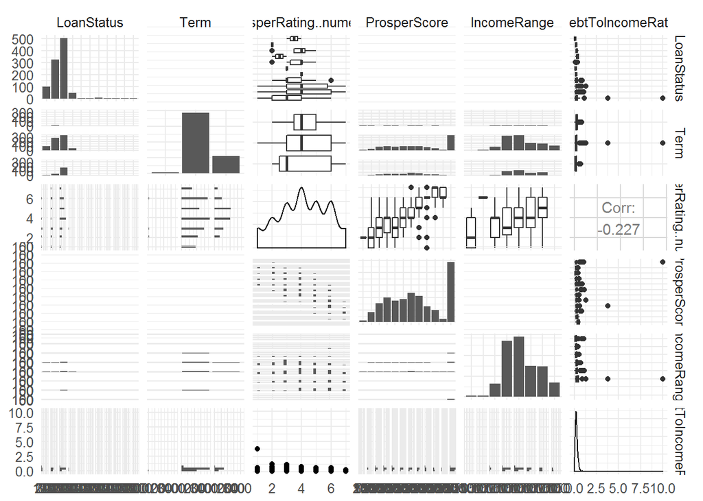

We can see in the first matrix the relation between lender yield and other variables. there are strong relationship (correlation -0.954)between lender yield and ProsperRating..numeric. . we can see the second Matrix don’t give additional information for loan status. it is useless.

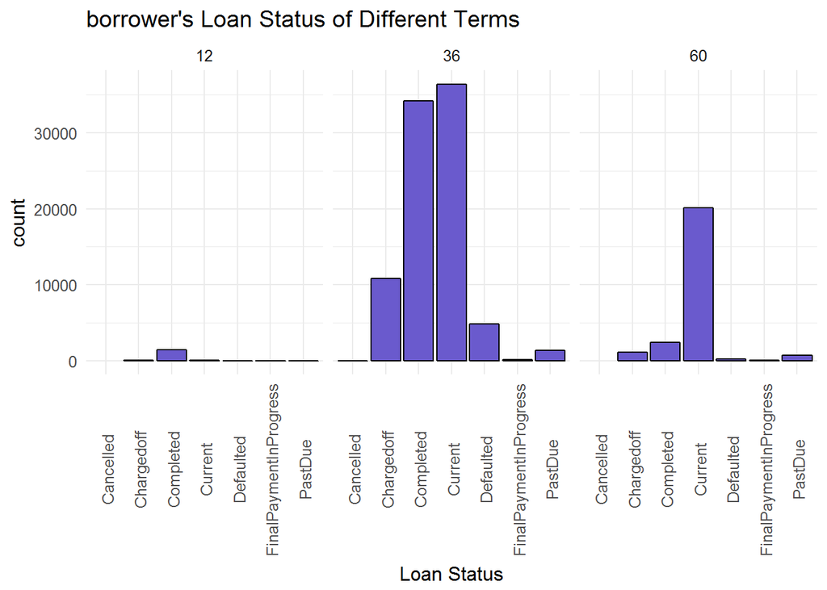

Here we can see a lot of outliers and the investors median of completed and chargedoff loans higher than other status.

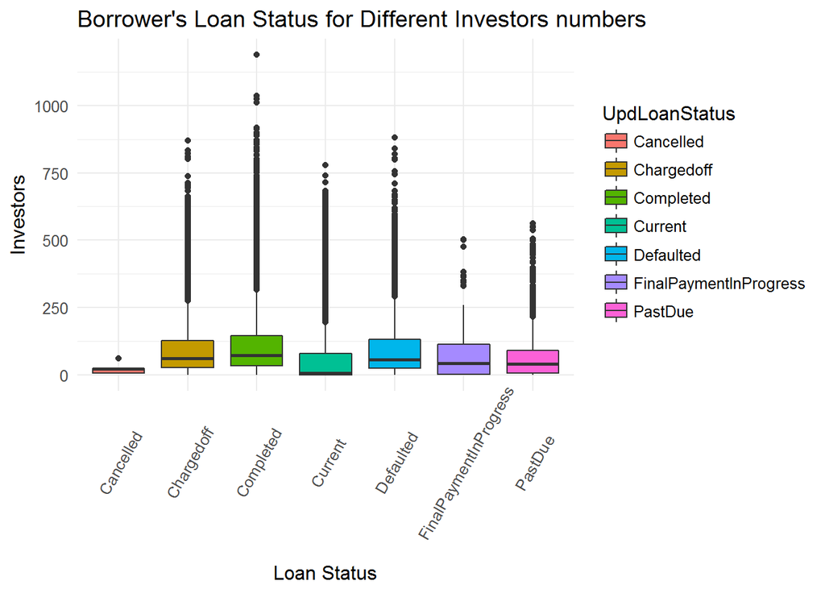

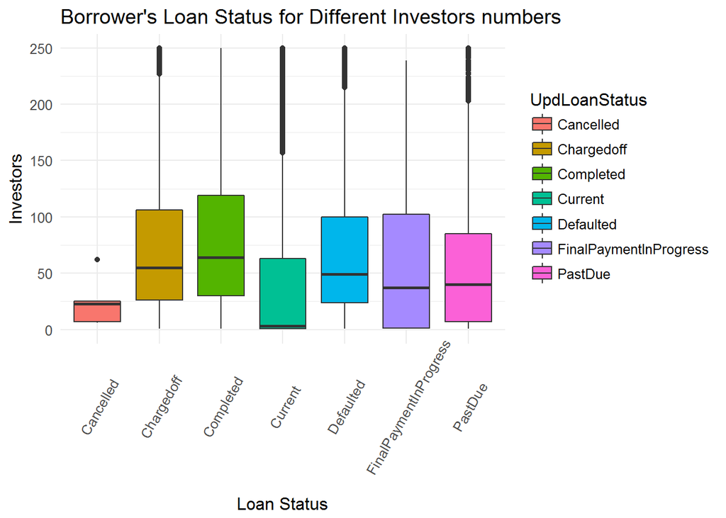

As what we see before the half of loans are under 0.25 ratio. the distribution of Past Due loan is not clear in this chart.

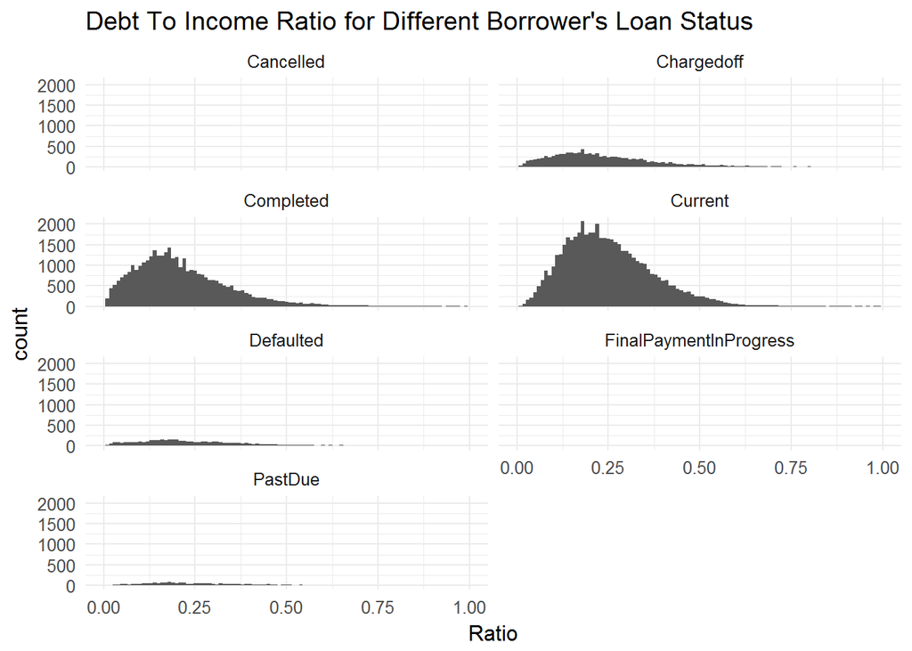

Past due loans have the same distribution of other status When we look closer to it.

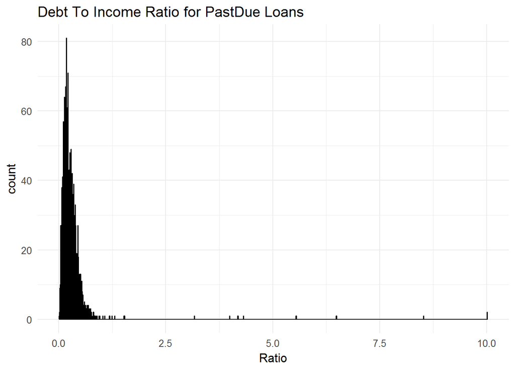

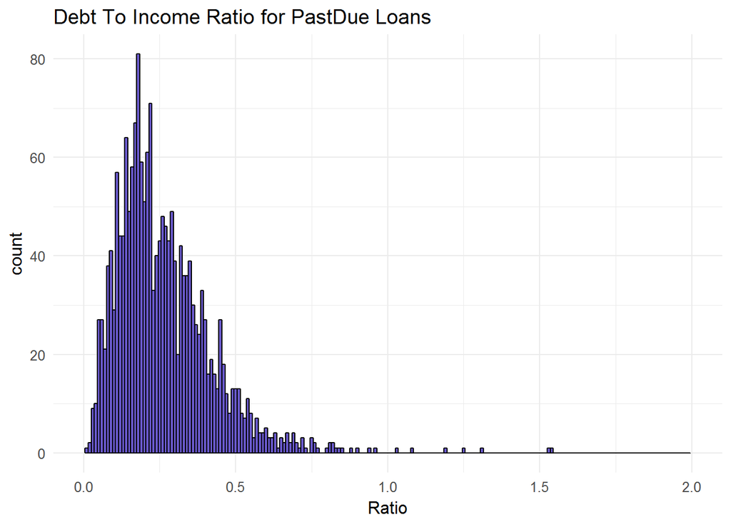

In general we can say that Defaulted is the same as Past Due loans but there are many loans in 10 ratio which the highest ratio allowed by prosper site. They may be did not intend to repay the debt.

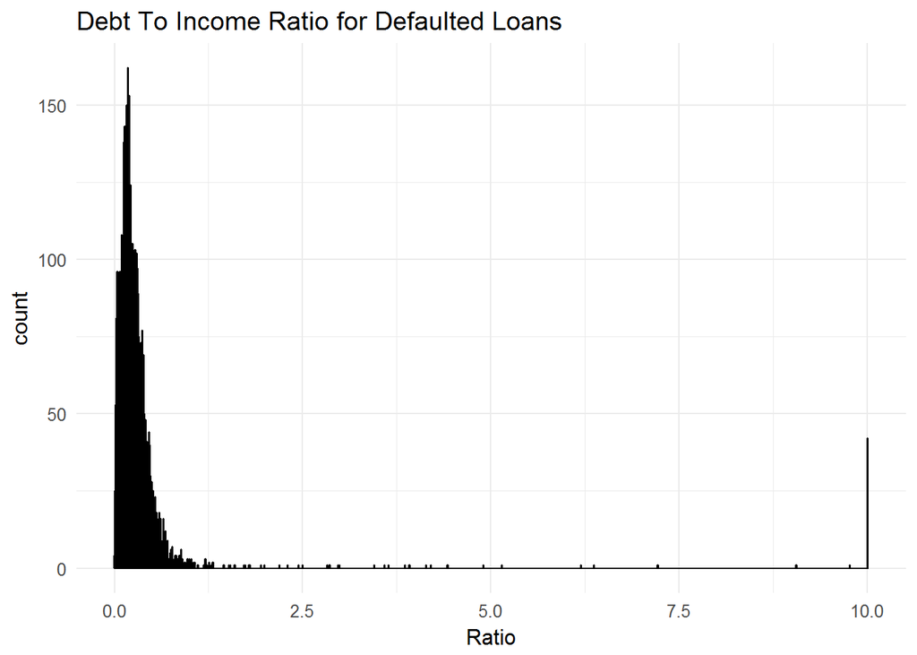

These charts show the income range for different loans status. The completed and charged off loans are more wide distribution.

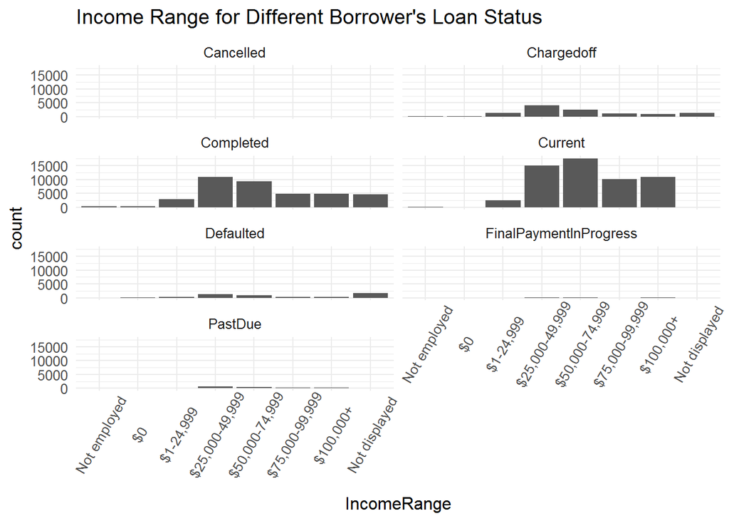

Now, we take a look to summary results. we can see there are huge gap between loan statuses.

```
## loandata$UpdLoanStatus: Cancelled
##   Not employed             $0      $1-24,999 $25,000-49,999 $50,000-74,999
##              0              0              0              1              0
## $75,000-99,999      $100,000+  Not displayed
##              0              0              4
## --------------------------------------------------------
## loandata$UpdLoanStatus: Chargedoff
##   Not employed             $0      $1-24,999 $25,000-49,999 $50,000-74,999
##            182            185           1329           4162           2633
## $75,000-99,999      $100,000+  Not displayed
##           1153            968           1380
## --------------------------------------------------------
## loandata$UpdLoanStatus: Completed
##   Not employed             $0      $1-24,999 $25,000-49,999 $50,000-74,999
##            325            370           2908          10891           9282
## $75,000-99,999      $100,000+  Not displayed
##           4914           4774           4610
## --------------------------------------------------------
## loandata$UpdLoanStatus: Current
##   Not employed             $0      $1-24,999 $25,000-49,999 $50,000-74,999
##            248             11           2536          15111          17615
## $75,000-99,999      $100,000+  Not displayed
##          10139          10916              0
## --------------------------------------------------------
## loandata$UpdLoanStatus: Defaulted
##   Not employed             $0      $1-24,999 $25,000-49,999 $50,000-74,999
##             25             51            334           1290            874
## $75,000-99,999      $100,000+  Not displayed
##            375            322           1747
## --------------------------------------------------------
## loandata$UpdLoanStatus: FinalPaymentInProgress
##   Not employed             $0      $1-24,999 $25,000-49,999 $50,000-74,999
##              0              0             14             49             64
## $75,000-99,999      $100,000+  Not displayed
##             26             52              0
## --------------------------------------------------------
## loandata$UpdLoanStatus: PastDue
##   Not employed             $0      $1-24,999 $25,000-49,999 $50,000-74,999
##             26              4            153            688            582
## $75,000-99,999      $100,000+  Not displayed
##            309            305              0
```

We can see income range for past due as same as general distribution